# Targeting Housing Subsidy

Dave Drennan

2023-11-17

# Introduction

Governments are tasked with maintaining a wide range of public services in a fiscally responsible manner. When proactive approaches to tax credit programs and connecting residents with the credits are taken, it’s our job in the Department of Housing and Community Development to make sure that our approach is both efficient and effective. For this home repair tax credit program, this approach means reaching eligible homeowners and maximizing the financial benefit of the credit without overspending on the administrative costs of outreach and counseling. Historically, our outreach efforts have been ad-hoc. By using a modeling approaching with historical data, we will pursue a strategy of identifying homeowners who are most likely to complete the full application process and take the credit while minimizing the outreach we do to residents who are unlikely to take the credit, thereby wasting taxpayer dollars.

# Data

```r
palette5 <- c("#981FAC","#CB0F8B","#FF006A","#FE4C35","#FE9900")
palette4 <- c("#981FAC","#FF006A","#FE4C35","#FE9900")
palette3 <- c("#981FAC","#FF006A","#FE4C35")
palette2 <- c("#981FAC","#FF006A")

HousingSubsidy <- read.csv("https://raw.githubusercontent.com/olivegardener/musa_5080_2023/main/Week_7/TargetingHousingSubsidy/data/housingSubsidy.csv")

# Filter the dataframe
HousingSubsidy <- subset(HousingSubsidy, taxLien != 'yes')
```

```r
HousingSubsidy <- HousingSubsidy %>%
  mutate(EnterProgram = ifelse(y == 'yes', 1, 0)) %>%
  dplyr::select(-y_numeric)
```

Our data is based on previous records of outreach and outcomes. We will seek to build a model that effectively targets eligible homeowners by finding characteristics (i.e. variables) that will make them more likely to enter the program and take the credit.

## Exploring data

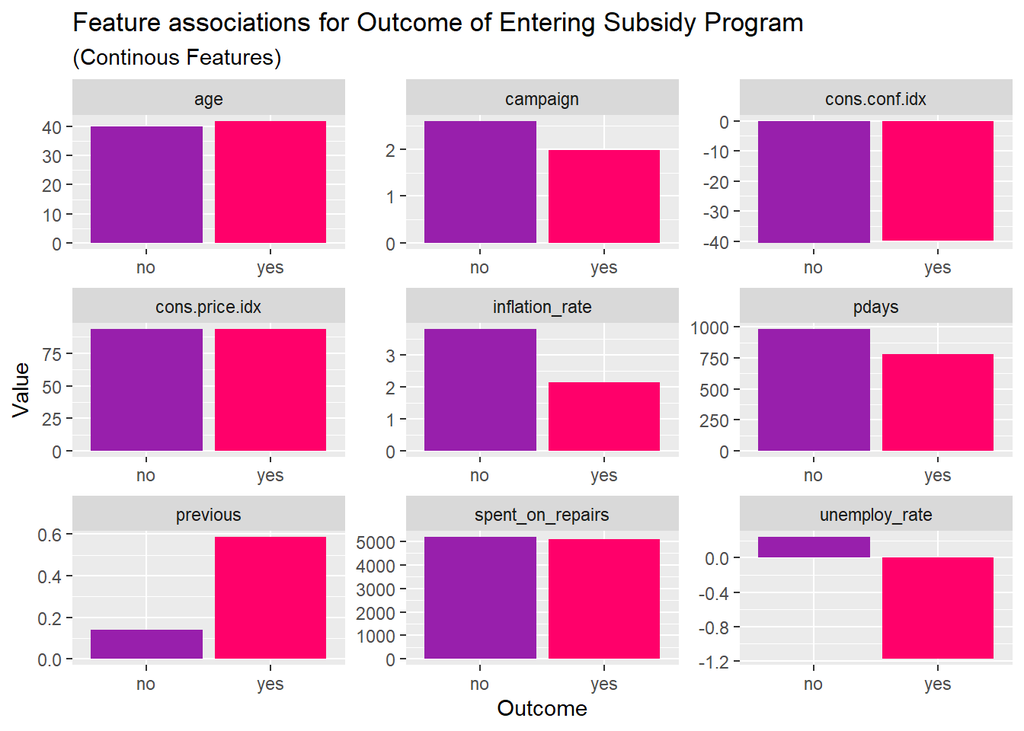

```r
HousingSubsidy %>%
  dplyr::select(y, age, campaign, pdays, previous, unemploy_rate, cons.price.idx, cons.conf.idx, inflation_rate, spent_on_repairs) %>%
  gather(Variable, value, -y) %>%
    ggplot(aes(y, value, fill=y)) +
      geom_bar(position = "dodge", stat = "summary", fun = "mean") +
      facet_wrap(~Variable, scales = "free") +
      scale_fill_manual(values = palette2) +
      labs(x="Outcome", y="Value",
           title = "Feature associations for Outcome of Entering Subsidy Program",
           subtitle = "(Continous Features)") +
      theme(legend.position = "none")
```

We start by plotting the numerical variables in bar plots. We’re most interested in variables that show a sizable contrast between no (did not enter program) and yes (did enter program) such as “previous”, because those features are more likely to better predict the outcomes of the homeowner taking the credit. A variable with nearly equal values for no and yes is more of a coin flip scenario as to whether someone will join the program or not based on that characteristic. However, these bar plots only capture the mean value per category of the responses from everyone in our sample. We will instead plot all responses p1er variable on density graphs below.

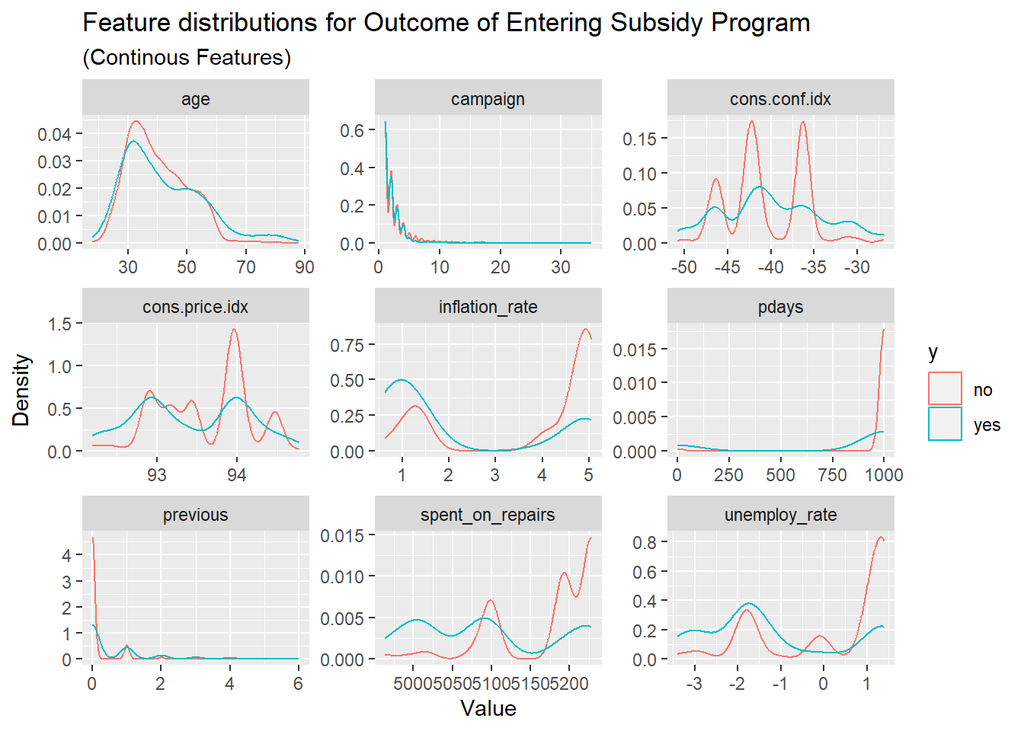

```r
HousingSubsidy %>%
    dplyr::select(y, age, campaign, pdays, previous, unemploy_rate, cons.price.idx, cons.conf.idx, inflation_rate, spent_on_repairs) %>%
    gather(Variable, value, -y) %>%
    ggplot() +
    geom_density(aes(value, color=y), fill = "transparent") +
    facet_wrap(~Variable, scales = "free") +
    scale_fill_manual(values = palette2) +
    labs(title = "Feature distributions for Outcome of Entering Subsidy Program",
         subtitle = "(Continous Features)",
         x="Value", y="Density")
```

These plots help us visualize the range of outcomes for different variables and help us to better understand nuances in the data, as well as pull out subsets that show the contrast between yes or no outcomes that will help us build a more predictive model. For example, the inflation rate shows potential based on the distinction between outcomes under and over 3% inflation.

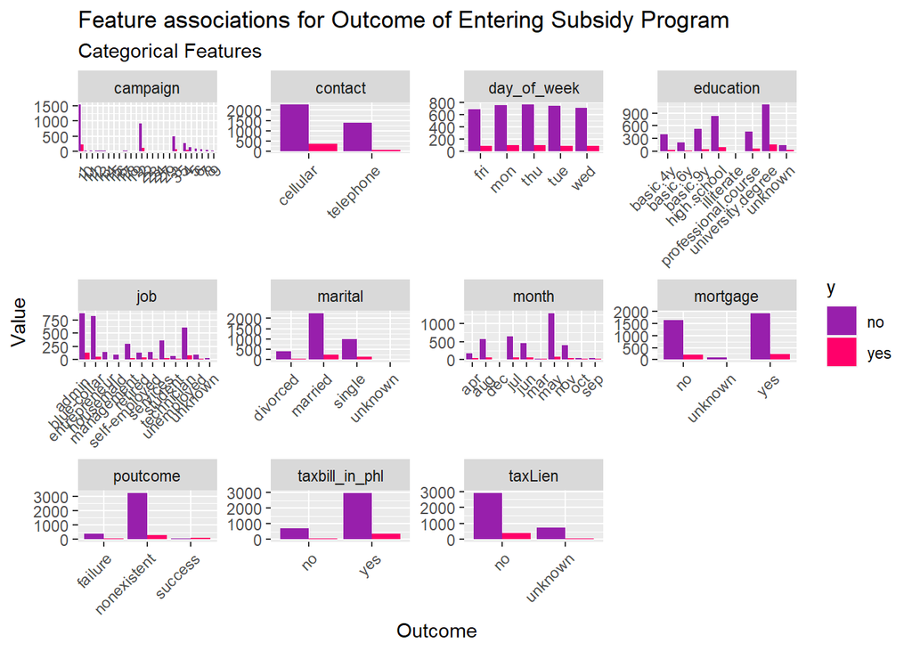

```r
HousingSubsidy %>%
    dplyr::select(y, job, marital, education, taxLien, mortgage, taxbill_in_phl, contact, month, day_of_week, campaign, poutcome) %>%
    gather(Variable, value, -y) %>%
    count(Variable, value, y) %>%
      ggplot(., aes(value, n, fill = y)) +
        geom_bar(position = "dodge", stat="identity") +
        facet_wrap(~Variable, scales="free") +
        scale_fill_manual(values = palette2) +
        labs(x="Outcome", y="Value",
             title = "Feature associations for Outcome of Entering Subsidy Program",
             subtitle = "Categorical Features") +
        theme(axis.text.x = element_text(angle = 45, hjust = 1))
```

Beyond the numeric variables in our sample data, we can also explore relationships between categorical variables. For example, we see in the outcomes for the “contact” variable that participants appear to be more likely to join the program if they are contacted by cell phone as opposed to by telephone. With these variables, it is important to also compare across the category in addition to looking at the difference between outcomes.

# Model

```r
set.seed(3456)
trainIndex <- createDataPartition(HousingSubsidy$y, p = .65,
                                  list = FALSE,
                                  times = 1)
SubsidyTrain <- HousingSubsidy[ trainIndex,]
SubsidyTest  <- HousingSubsidy[-trainIndex,]
```

```r
SubsidyModel <- glm(EnterProgram ~ .,
                  data=SubsidyTrain %>%
                    dplyr::select(-y, -X),
                  family="binomial" (link="logit"))
```

We start by running a model that uses all of the features in our sample data. We will refer to this as the “kitchen sink” model. As part of initial testing, we found that this model is not particularly effective at identifying the true positive rate, or number of people who we marketed to that actually entered the program, which means that the model’s sensitivity is low.

We will develop new features based on the existing variables in our data set in order to make a more sensitive model. We can determine how well we do at engineering new features by examining the the AIC score that is generated by the regression output - for this metric, lower is better.

## Feature Engineering

```r
HousingSubsidy2 <- HousingSubsidy %>%
  mutate(MarchOrNot = ifelse(month == "mar", 1, 0)) %>%
  mutate(SingleOrNot = ifelse(marital == "single", 1, 0)) %>%
  mutate(WedOrNot = ifelse(day_of_week == "wed", 1, 0)) %>%
  dplyr::select(-month, -job, -education, -marital, -taxLien, -pdays, -taxbill_in_phl, -mortgage, -campaign, -previous, -day_of_week, -X)
```

```r
set.seed(3456)
trainIndex2 <- createDataPartition(HousingSubsidy2$y, p = .65,
                                  list = FALSE,
                                  times = 1)
SubsidyTrain2 <- HousingSubsidy2[ trainIndex2,]
SubsidyTest2  <- HousingSubsidy2[-trainIndex2,]
```

```r
SubsidyModel2 <- glm(EnterProgram ~ .,
                  data=SubsidyTrain2 %>%
                    dplyr::select(-y),
                  family="binomial" (link="logit"))
```

```r
HousingSubsidy3 <- HousingSubsidy %>%
  mutate(SingleOrNot = ifelse(marital == "single", 1, 0),
         season =
           case_when(month == "dec" | month == "jan" | month == "feb"~ "Winter",
                     month == "mar" | month == "apr" | month == "may"~ "Spring",
                     month == "jun" | month == "jul" | month == "aug"~ "Summer",
                     month == "sep" | month == "oct" | month == "nov"~ "Fall"
           ),
         campaign_cat =
           case_when(campaign == 1 ~ "one",
                     campaign == 2 ~ "two",
                     campaign == 3 ~ "three",
                     campaign >= 4 ~ "four+"),
         pdays_cat =
           case_when(pdays == 999 ~ "No contact",
                     pdays <= 14 ~ "Within 2 weeks",
                     pdays > 14 & pdays <=30 ~ "Between 2 weeks and 1 month"),
         inflation_split =
           case_when(inflation_rate >= 3 ~ "3%+",
                     inflation_rate < 3 ~ "<3%")
         ) %>%
  dplyr::select(-month, -job, -education, -marital, -taxLien, -pdays, -taxbill_in_phl, -mortgage, -campaign, -previous, -day_of_week, -inflation_rate, -X)
```

```r
set.seed(3456)
trainIndex3 <- createDataPartition(HousingSubsidy3$y, p = .65,
                                  list = FALSE,
                                  times = 1)
SubsidyTrain3 <- HousingSubsidy3[ trainIndex3,]
SubsidyTest3  <- HousingSubsidy3[-trainIndex3,]
```

```r
SubsidyModel3 <- glm(EnterProgram ~ .,
                  data=SubsidyTrain3 %>%
                    dplyr::select(-y),
                  family="binomial" (link="logit"))
```

### Feature Engineering

- Season, to capture more generalizable categories for time of year (winter, spring, summer, fall),
- Campaign category, to provide a count of the number of times that an individual was contacted during this sample campaign data as once, twice, three times, or four or more times,
- pdays category for the number of days that an individual was contacted from a previous program as never, within the previous two weeks, or between two to four weeks, and
- Inflation split, which classifies inflation as over or under 3%, which is roughly considered high or low inflation based on the U.S. Federal Reserve’s long term inflation goals

### Regression Summaries

```r
summary(SubsidyModel)
```

```
##
## Call:
## glm(formula = EnterProgram ~ ., family = binomial(link = "logit"),
##     data = SubsidyTrain %>% dplyr::select(-y, -X))
##
## Coefficients:
##                                  Estimate   Std. Error z value Pr(>|z|)
## (Intercept)                   -74.2894054  127.7455033  -0.582  0.56088
## age                             0.0105729    0.0084504   1.251  0.21088
## jobblue-collar                 -0.1980289    0.2710573  -0.731  0.46504
## jobentrepreneur                -0.2941650    0.4360779  -0.675  0.49995
## jobhousemaid                   -0.9095231    0.6000869  -1.516  0.12961
## jobmanagement                  -0.7671373    0.3313465  -2.315  0.02060 *
## jobretired                     -0.4317440    0.3888583  -1.110  0.26688
## jobself-employed               -0.8762971    0.4835378  -1.812  0.06995 .
## jobservices                    -0.2074848    0.2924565  -0.709  0.47804
## jobstudent                     -0.7786988    0.5049361  -1.542  0.12303
## jobtechnician                  -0.0395759    0.2301124  -0.172  0.86345
## jobunemployed                  -0.0345097    0.4197724  -0.082  0.93448
## jobunknown                     -0.4055237    0.6850445  -0.592  0.55387
## maritalmarried                  0.1575736    0.2500692   0.630  0.52862
## maritalsingle                   0.2235653    0.2830382   0.790  0.42960
## maritalunknown                -12.6522482  463.3517173  -0.027  0.97822
## educationbasic.6y               0.3708987    0.4149654   0.894  0.37143
## educationbasic.9y               0.1674527    0.3344455   0.501  0.61659
## educationhigh.school            0.2185017    0.3292872   0.664  0.50697
## educationilliterate           -13.7941654 1455.3976473  -0.009  0.99244
## educationprofessional.course    0.3978191    0.3460730   1.150  0.25034
## educationuniversity.degree      0.3387521    0.3282838   1.032  0.30212
## educationunknown                0.5254461    0.4023984   1.306  0.19163
## taxLienunknown                  0.1108452    0.2113693   0.524  0.59999
## mortgageunknown                -0.4268377    0.6063508  -0.704  0.48147
## mortgageyes                    -0.1885646    0.1432463  -1.316  0.18805
## taxbill_in_phlyes               0.1190006    0.1977159   0.602  0.54726
## contacttelephone               -0.6161809    0.2822840  -2.183  0.02905 *
## monthaug                        0.2134428    0.4319597   0.494  0.62122
## monthdec                        1.4906440    0.7027917   2.121  0.03392 *
## monthjul                       -0.0396059    0.3723348  -0.106  0.91529
## monthjun                        0.0507407    0.4527275   0.112  0.91076
## monthmar                        1.4919465    0.5588681   2.670  0.00759 **
```

[output cut: 13 more lines]

```
## unemploy_rate                  -0.9849794    0.4726538  -2.084  0.03717 *
## cons.price.idx                  0.9921846    0.8380982   1.184  0.23647
## cons.conf.idx                   0.0158501    0.0282201   0.562  0.57435
## inflation_rate                  0.4790009    0.4379010   1.094  0.27402
## spent_on_repairs               -0.0042876    0.0104113  -0.412  0.68047
## ---
## Signif. codes:  0 '***' 0.001 '**' 0.01 '*' 0.05 '.' 0.1 ' ' 1
##
## (Dispersion parameter for binomial family taken to be 1)
##
##     Null deviance: 1853.5  on 2677  degrees of freedom
## Residual deviance: 1477.1  on 2627  degrees of freedom
## AIC: 1579.1
##
## Number of Fisher Scoring iterations: 14
```

```r
summary(SubsidyModel2)
```

```
##
## Call:
## glm(formula = EnterProgram ~ ., family = binomial(link = "logit"),
##     data = SubsidyTrain2 %>% dplyr::select(-y))
##
## Coefficients:
##                        Estimate  Std. Error z value       Pr(>|z|)
## (Intercept)         -170.012718   53.773690  -3.162        0.00157 **
## age                    0.006959    0.006795   1.024        0.30574
## contacttelephone      -0.905881    0.216200  -4.190 0.000027893748 ***
## poutcomenonexistent    0.578947    0.216502   2.674        0.00749 **
## poutcomesuccess        1.822897    0.289742   6.291 0.000000000315 ***
## unemploy_rate         -0.995720    0.225068  -4.424 0.000009684781 ***
## cons.price.idx         1.559120    0.352814   4.419 0.000009911173 ***
## cons.conf.idx          0.062355    0.020594   3.028        0.00246 **
## inflation_rate         0.020075    0.283791   0.071        0.94360
## spent_on_repairs       0.004574    0.004833   0.946        0.34397
## MarchOrNot             1.800282    0.426448   4.222 0.000024260311 ***
## SingleOrNot            0.096947    0.167503   0.579        0.56274
## WedOrNot               0.022391    0.177897   0.126        0.89984
## ---
## Signif. codes:  0 '***' 0.001 '**' 0.01 '*' 0.05 '.' 0.1 ' ' 1
##
## (Dispersion parameter for binomial family taken to be 1)
##
##     Null deviance: 1853.5  on 2677  degrees of freedom
## Residual deviance: 1525.1  on 2665  degrees of freedom
## AIC: 1551.1
##
## Number of Fisher Scoring iterations: 5
```

```r
summary(SubsidyModel3)
```

```
##
## Call:
## glm(formula = EnterProgram ~ ., family = binomial(link = "logit"),
##     data = SubsidyTrain3 %>% dplyr::select(-y))
##
## Coefficients:
##                           Estimate Std. Error z value Pr(>|z|)
## (Intercept)             -47.103475  71.425429  -0.659  0.50959
## age                       0.007638   0.006764   1.129  0.25881
## contacttelephone         -0.653228   0.263688  -2.477  0.01324 *
## poutcomenonexistent       0.602553   0.223197   2.700  0.00694 **
## poutcomesuccess           0.877092   0.766817   1.144  0.25270
## unemploy_rate            -0.739870   0.238914  -3.097  0.00196 **
## cons.price.idx            0.786169   0.467545   1.681  0.09267 .
## cons.conf.idx             0.016284   0.029299   0.556  0.57835
## spent_on_repairs         -0.006017   0.006203  -0.970  0.33201
## SingleOrNot               0.139970   0.167243   0.837  0.40264
## seasonSpring              0.473895   0.351664   1.348  0.17779
## seasonSummer              0.782739   0.370254   2.114  0.03451 *
## seasonWinter              1.732036   0.590129   2.935  0.00334 **
## campaign_catone           0.349758   0.211871   1.651  0.09878 .
## campaign_catthree         0.245407   0.265229   0.925  0.35483
## campaign_cattwo           0.113398   0.235658   0.481  0.63038
## pdays_catNo contact       0.560793   1.071091   0.524  0.60058
## pdays_catWithin 2 weeks   1.611254   0.939157   1.716  0.08623 .
## inflation_split3%+        1.291567   1.197041   1.079  0.28060
## ---
## Signif. codes:  0 '***' 0.001 '**' 0.01 '*' 0.05 '.' 0.1 ' ' 1
##
## (Dispersion parameter for binomial family taken to be 1)
##
##     Null deviance: 1853.5  on 2677  degrees of freedom
## Residual deviance: 1522.1  on 2659  degrees of freedom
## AIC: 1560.1
##
## Number of Fisher Scoring iterations: 5
```

We run all three of our models and compare AIC scores to see which model better reflects our data. The AIC score for the kitchen sink model is 1579, for the second model is 1551. and for the third model 1560. While the second model, with the engineering features for March or not and Wednesday or not, technically has the lowest score, we will use the third model for our analysis. The third model has a lower (and therefore better) AIC value compared to the kitchen sink model while using new features that could be considered more generalizable in different contexts.

It is possible that the significance of March or Wednesdays could be a reflection of quirks in the data gathering process and are difficult to decipher without additional context that is not reflected in the data set.

Model 3 will be referred to as the engineered regression for the rest of this report.

# Cross Validation

## Kitchen Sink Model

```r
ctrl1 <- trainControl(method = "cv", number = 100, classProbs=TRUE, summaryFunction=twoClassSummary)

cvFit1 <- train(y ~ .,
                  data=HousingSubsidy %>%
                    dplyr::select(-EnterProgram, -X),
                method="glm", family="binomial",
                metric="ROC", trControl = ctrl1)

cvFit1
```

```
## Generalized Linear Model
##
## 4118 samples
##   19 predictor
##    2 classes: 'no', 'yes'
##
## No pre-processing
## Resampling: Cross-Validated (100 fold)
## Summary of sample sizes: 4078, 4077, 4076, 4077, 4077, 4076, ...
## Resampling results:
##
##   ROC        Sens       Spec
##   0.7643904  0.9800751  0.219
```

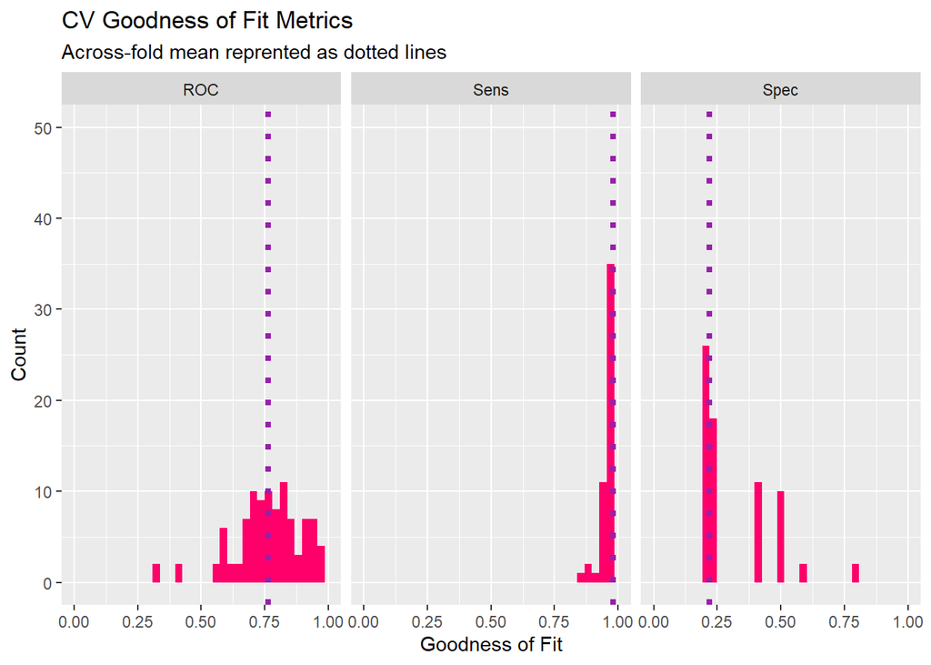

```r
dplyr::select(cvFit1$resample, -Resample) %>%
  gather(metric, value) %>%
  left_join(gather(cvFit1$results[2:4], metric, mean)) %>%
  ggplot(aes(value)) +
    geom_histogram(bins=35, fill = "#FF006A") +
    facet_wrap(~metric) +
    geom_vline(aes(xintercept = mean), colour = "#981FAC", linetype = 3, size = 1.5) +
    scale_x_continuous(limits = c(0, 1)) +
    labs(x="Goodness of Fit", y="Count", title="CV Goodness of Fit Metrics",
         subtitle = "Across-fold mean reprented as dotted lines")
```

## Engineered Regression Model

```r
ctrl3 <- trainControl(method = "cv", number = 100, classProbs=TRUE, summaryFunction=twoClassSummary)

cvFit3 <- train(y ~ .,
                  data=HousingSubsidy3 %>%
                    dplyr::select(-EnterProgram),
                method="glm", family="binomial",
                metric="ROC", trControl = ctrl3)

cvFit3
```

```
## Generalized Linear Model
##
## 4118 samples
##   12 predictor
##    2 classes: 'no', 'yes'
##
## No pre-processing
## Resampling: Cross-Validated (100 fold)
## Summary of sample sizes: 4076, 4077, 4076, 4077, 4077, 4077, ...
## Resampling results:
##
##   ROC        Sens     Spec
##   0.7797136  0.98497  0.2165
```

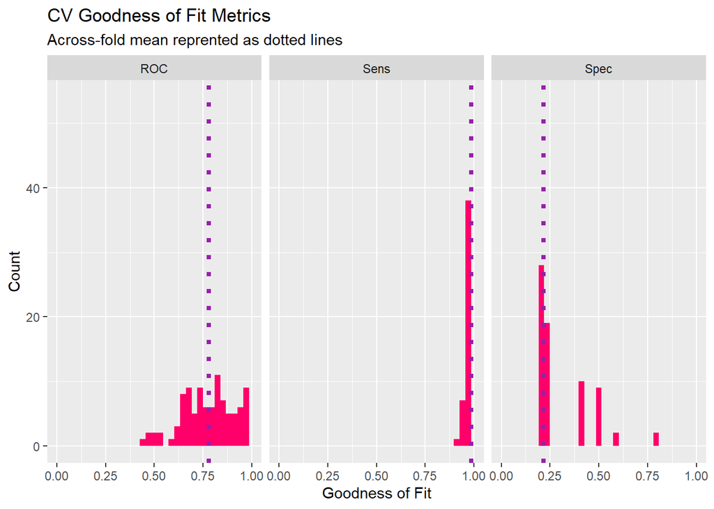

```r
dplyr::select(cvFit3$resample, -Resample) %>%
  gather(metric, value) %>%
  left_join(gather(cvFit3$results[2:4], metric, mean)) %>%
  ggplot(aes(value)) +
    geom_histogram(bins=35, fill = "#FF006A") +
    facet_wrap(~metric) +
    geom_vline(aes(xintercept = mean), colour = "#981FAC", linetype = 3, size = 1.5) +
    scale_x_continuous(limits = c(0, 1)) +
    labs(x="Goodness of Fit", y="Count", title="CV Goodness of Fit Metrics",
         subtitle = "Across-fold mean reprented as dotted lines")
```

# ROC Curve

```r
testProbs <- data.frame(Outcome = as.factor(SubsidyTest$EnterProgram),
                        Probs = predict(SubsidyModel, SubsidyTest, type= "response"))

testProbs2 <- data.frame(Outcome = as.factor(SubsidyTest2$EnterProgram),
                        Probs = predict(SubsidyModel2, SubsidyTest2, type= "response"))

testProbs3 <- data.frame(Outcome = as.factor(SubsidyTest3$EnterProgram),
                        Probs = predict(SubsidyModel2, SubsidyTest2, type= "response"))
```

## Area Under Curve

```r
pROC::auc(testProbs3$Outcome, testProbs3$Probs)
```

```
## Area under the curve: 0.8183
```

## ROC Curve Plot

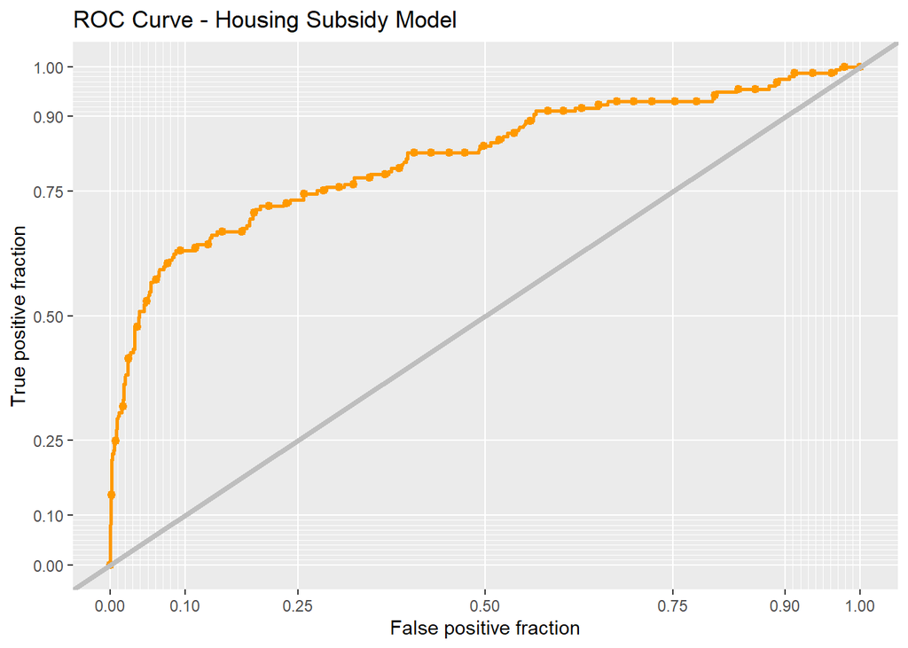

```r
ggplot(testProbs3, aes(d = as.numeric(Outcome), m = Probs)) +
  geom_roc(n.cuts = 50, labels = FALSE, colour = "#FE9900") +
  style_roc(theme = theme_grey) +
  geom_abline(slope = 1, intercept = 0, size = 1.5, color = 'grey') +
  labs(title = "ROC Curve - Housing Subsidy Model")
```

The ROC curve is a reflection of our two most important metrics - true positive responses and false positive responses. False positives are people that we marketed to that did not attempt to enter the housing credit program.

This curve allows us to understand the different thresholds of correctly versus incorrectly predicting that someone will enter the program. Our goal is for the area under the curve of our line of predicted outcome thresholds to be near 1 but not at 1. A value of 1 indicates that we’re overfitting the data, meaning it is not generalizable to new data. We also want to be above the diagonal line, which represents 0.5 - in other words, a coin flip of correctly predicting the outcome or predicting worse that a coin flip if below that line.

# Cost Benefit Analysis

## Confusion Matrix

```r
testProbs3 <-
  testProbs3 %>%
  mutate(predOutcome  = as.factor(ifelse(testProbs3$Probs > 0.5 , 1, 0)))
```

```r
caret::confusionMatrix(testProbs3$predOutcome, testProbs3$Outcome,
                       positive = "1")
```

```
## Confusion Matrix and Statistics
##
##           Reference
## Prediction    0    1
##          0 1277  122
##          1    6   35
##
##                Accuracy : 0.9111
##                  95% CI : (0.8952, 0.9253)
##     No Information Rate : 0.891
##     P-Value [Acc > NIR] : 0.006797
##
##                   Kappa : 0.323
##
##  Mcnemar's Test P-Value : < 0.00000000000000022
##
##             Sensitivity : 0.22293
##             Specificity : 0.99532
##          Pos Pred Value : 0.85366
##          Neg Pred Value : 0.91279
##              Prevalence : 0.10903
##          Detection Rate : 0.02431
##    Detection Prevalence : 0.02847
##       Balanced Accuracy : 0.60913
##
##        'Positive' Class : 1
##
```

## Cost-Benefit Outcomes

To determine outcomes and costs, we develop a series of cost-benefits equations that reflect the four possibilities in our data:

- True negative revenue “Predicted correctly homeowner would not take the credit, no marketing resources were allocated, and no credit was allocated.”: -$0
- True positive revenue “Predicted correctly homeowner would enter credit program; allocated the marketing resources, and 25% ultimately achieved the credit”: -$2,850 + $5,000 = $2,150 return for 25% of cases that take the credit. -$2,850 for 75% of cases who did not take the credit.
- False negative revenue “Predicted that a homeowner would not take the credit but they did. These are likely homeowners who signed up for reasons unrelated to the marketing campaign”: $0
- False positive revenue “Predicted incorrectly homeowner would take the credit; allocated marketing resources; no credit allocated.”: -$2,850

The best outcomes are true positive and true negative outcomes - these scenarios are where our model was accurate. False negatives are a neutral outcome since they occur outside of our marketing campaign predictions. False positives are the worst outcome - we allocated marketing resources only to be incorrect in our prediction that the homeowner would enter the credit program.

For the purposes of cost, we define negative value investments as the marketing and administrative costs associated with outreach to individuals. We define positive value investments as the awarding of a credit to an individual, minus the marketing and administrative cost associated with it. By virtue of this program being a subsidy program, it does not directly generate revenue. Therefore, our goal is maximizing positive investments by the HCD while minimizing negative investments.

```r
cost_benefit_table <-
   testProbs3 %>%
      count(predOutcome, Outcome) %>%
      summarize(True_Negative = sum(n[predOutcome==0 & Outcome==0]),
                True_Positive = sum(n[predOutcome==1 & Outcome==1]),
                False_Negative = sum(n[predOutcome==0 & Outcome==1]),
                False_Positive = sum(n[predOutcome==1 & Outcome==0])) %>%
       gather(Variable, Count) %>%
       mutate(Revenue =
               ifelse(Variable == "True_Negative", Count * 0,
               ifelse(Variable == "True_Positive", (Count * .25 * (-2850+5000)) + (Count * .75 * -2850),
               ifelse(Variable == "False_Negative", Count * 0,
               ifelse(Variable == "False_Positive", (Count * -2850), 0))))) %>%
    bind_cols(data.frame(Description = c(
              "We correctly predicted no enrollment",
              "We correctly predicted enrollment",
              "We predicted no enrollment and person enrolled",
              "We predicted enrollment and customer did not enroll")))

kable(cost_benefit_table,
       caption = "Cost/Benefit Table") %>% kable_styling()
```

Cost/Benefit Table

| Variable | Count | Revenue | Description |
| --- | --- | --- | --- |
| True_Negative | 1277 | 0 | We correctly predicted no enrollment |
| True_Positive | 35 | -56000 | We correctly predicted enrollment |
| False_Negative | 122 | 0 | We predicted no enrollment and person enrolled |
| False_Positive | 6 | -17100 | We predicted enrollment and customer did not enroll |

## Confusion Metric Outcomes by Threshold

```r
whichThreshold <-
  iterateThresholds(
     data=testProbs3, observedClass = Outcome, predictedProbs = Probs)

whichThreshold[1:5,]
```

```
## # A tibble: 5 × 10
##   Count_TN Count_TP Count_FN Count_FP Rate_TP Rate_FP Rate_FN Rate_TN Accuracy
##      <int>    <int>    <int>    <int>   <dbl>   <dbl>   <dbl>   <dbl>    <dbl>
## 1        0      157        0     1283   1       1     0       0          0.109
## 2        5      157        0     1278   1       0.996 0       0.00390    0.112
## 3       39      156        1     1244   0.994   0.970 0.00637 0.0304     0.135
## 4       52      155        2     1231   0.987   0.959 0.0127  0.0405     0.144
## 5      490      143       14      793   0.911   0.618 0.0892  0.382      0.440
## # ℹ 1 more variable: Threshold <dbl>
```

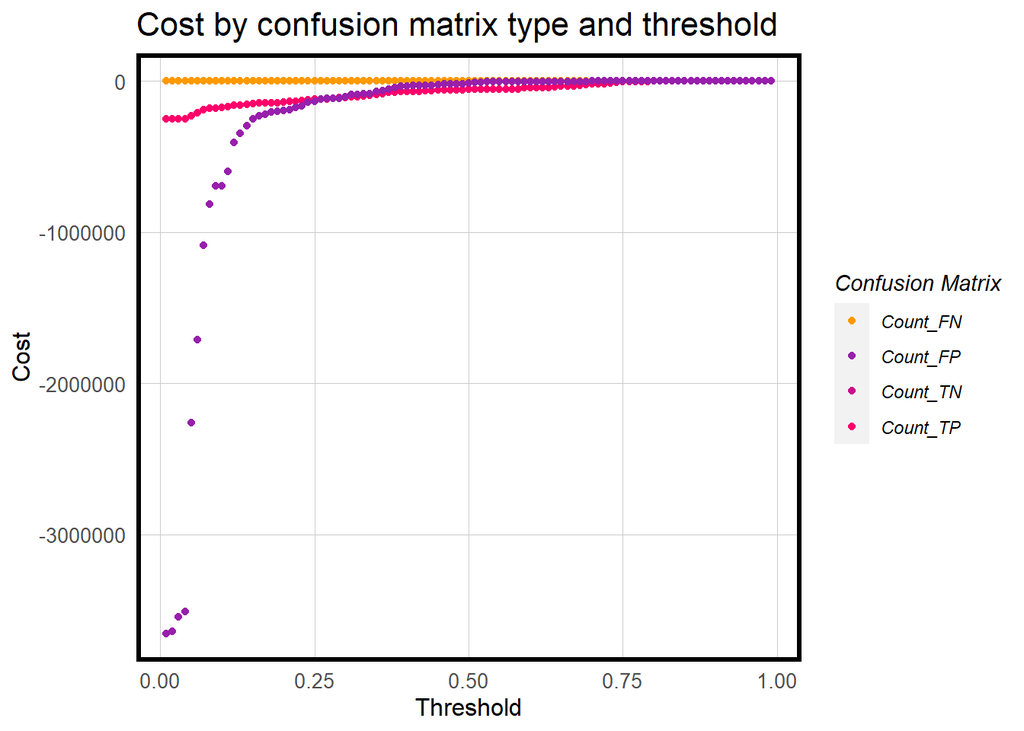

```r
whichThreshold <-
  whichThreshold %>%
    dplyr::select(starts_with("Count"), Threshold) %>%
    gather(Variable, Count, -Threshold) %>%
    mutate(Revenue =
             case_when(Variable == "Count_TN"  ~ Count * 0,
                       Variable == "Count_TP"  ~ (Count * .25 * (-2850+5000)) + (Count * .75 * -2850) +
                                                 (-32 * (Count * .50)),
                       Variable == "Count_FN"  ~ Count * 0,
                       Variable == "Count_FP"  ~ (Count * -2850)))

whichThreshold %>%
  ggplot(.,aes(Threshold, Revenue, colour = Variable)) +
  geom_point() +
  scale_colour_manual(values = palette5[c(5, 1:3)]) +
  labs(title = "Cost by confusion matrix type and threshold",
       y = "Cost") +
  plotTheme() +
  guides(colour=guide_legend(title = "Confusion Matrix"))
```

These costs by threshold show that false positives are the largest driver of steep costs to the program and can lead to steep negative investments at lower thresholds. While minimizing these costs is important for us in our role as the municipal government, this metric does not capture the number of credits awarded, only program costs.

## Plots of Revenue and Credits Thresholds

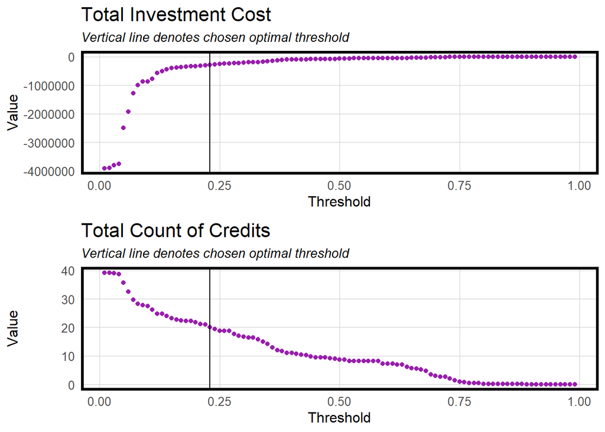

```r
whichThreshold_revenue <-
  whichThreshold %>%
    mutate(Count = ifelse(Variable == "Count_TP", (Count * .25),0)) %>%
    group_by(Threshold) %>%
    summarize(Total_Revenue = sum(Revenue),
              Total_Count_of_Credits = sum(Count))

#whichThreshold_revenue

fiftyThreshold = whichThreshold_revenue[50,]
optimalThreshold = whichThreshold_revenue[23,]
tableThreshold = rbind(fiftyThreshold, optimalThreshold)



rev_threshold <- whichThreshold_revenue %>%
  dplyr::select(Threshold, Total_Revenue) %>%
  gather(Variable, Value, -Threshold) %>%
  ggplot(aes(Threshold, Value, colour = Variable)) +
    geom_point() +
    geom_vline(xintercept = pull(arrange(optimalThreshold, -Total_Revenue)[1,1])) +
    scale_colour_manual(values = palette2) +
    plotTheme() +
    theme(legend.position = "none") +
    labs(title = "Total Investment Cost",
         subtitle = "Vertical line denotes chosen optimal threshold")

count_threshold <- whichThreshold_revenue %>%
  dplyr::select(Threshold, Total_Count_of_Credits) %>%
  gather(Variable, Value, -Threshold) %>%
  ggplot(aes(Threshold, Value, colour = Variable)) +
    geom_point() +
    geom_vline(xintercept = pull(arrange(optimalThreshold, -Total_Count_of_Credits)[1,1])) +
    scale_colour_manual(values = palette2) +
    plotTheme() +
    theme(legend.position = "none") +
    labs(title = "Total Count of Credits",
         subtitle = "Vertical line denotes chosen optimal threshold")

plot_grid(rev_threshold, count_threshold, ncol = 1, align = "v")
```

These plots align to show the cost and number of credits awarded at each threshold. Costs decrease as less credits are awarded, especially between the 0.0 and 0.15 thresholds, which is a reflection of false positive predictions decreasing.

We also show what we determine to be the optimal threshold, which we discuss further in the following section.

## Table of Revenue and Credits 50% and Optimal Thresholds

```r
tableThreshold %>% kbl() %>% kable_minimal()
```

| Threshold | Total_Revenue | Total_Count_of_Credits |
| --- | --- | --- |
| 0.50 | -73660 | 8.75 |
| 0.23 | -294580 | 20.00 |

We have chosen our optimal threshold to be 0.23. While the marginal cost per credit increases - the cost is four times greater for less than three times the credits compared to the 0.50 threshold - we believe that this threshold limits the steepest costs associated with a high number of false positive responses while effectively increasing the number of credits awarded.

# Conclusion

Our model is effective at limiting the number of false positive predictions, which are the worst outcome for our marketing program. Our department’s money is better spent on the credits themselves - positive investments worth $5,000 for home repairs - versus the marketing and administrative costs of $2,850 per homeowner.

Academic research has found that homeowners who enter the program and take the credit see an average increase in value of $10,000, with nearby homes surrounding the property seeing an average aggregate premium of $56,000. While these premiums are substantial and show the value of these subsidies we offer, we can’t account for them directly in our model because they are benefits outside the model that are dependent on when the homeowner chooses to conduct a transaction.

Our model could be improved and optimized if we were given a budget for the total amount of money that the HCD can spend on this credit program - the thresholds can then be selected based on costs that adhere to this budget. Additionally, spatial information in our data set would allow us to see if certain areas, either based on geography or demographics if we pull in Census data, are clustered in any meaningful way. If we find that certain groups are more likely to join the program but ultimately not take the credit, we can adjust our marketing and administrative processes to better target those populations with our outreach.

Additionally, we should find ways to limit the administrative costs and decrease the percentage of people who do not take the credit after entering the program. Considering we have a number of people who ultimately don’t receive the credit due to issues like faulty paperwork, our counseling and information sessions should be made more effective. With how much we are spending per homeowner, more emphasis should be placed on individual reviews or assistance to iron out these issues.